# apc: An R Package for Age-Period-Cohort Analysis

The *apc* package includes functions for age-period-cohort analysis based on the canonical parametrisation of Kuang et al. (2008b). The package includes functions for organizing the data, descriptive plots, a deviance table, estimation of (sub-models of) the age-period-cohort model, a plot for specification testing, plots of estimated parameters, and sub-sample analysis.

Bent Nielsen (Nuffield College, Oxford OX1 1NF, UK)  
2015-08-05

## 1 Introduction

Age-period-cohort models are extensively used in actuarial sciences, demography, epidemiology and social sciences. They have an identification problem in that the predictor is defined from time effects for age, period and cohort, but these time effects cannot be fully recovered from the predictor. The [*apc*](https://CRAN.R-project.org/package=apc) package, see Nielsen (2015a), implements the solution proposed by Kuang et al. (2008b) and Nielsen (2014), which is to abandon the time effects and reparametrise the predictor in terms of freely varying parameters. The vector of freely varying parameters is of a lower dimension than the vector of the original time effects. These freely varying parameters describe the variation of the likelihood function fully. The intention with the package is to focus on the aspects of the time effect that are identified by the likelihood.

The age-period-cohort model has three time scales: $age$, $period$ and $cohort$. These are linked through the identity $age+cohort=period$. The package is concerned with the situation where two of the time scales are measured in discrete and equidistant time. The third time scale can then be computed through $age+cohort=period$. The choice of these two indices vary from application to application. For instance, the example in this paper is a an age-period array of annual counts of mesothelioma deaths by age group. The interface of the package is constructed in such a way that the user does not need to keep track of the coordinate system. Internally, the package uses an age-cohort coordinate system to exploit that period is a symmetric function of age and cohort.

The statistical model is a generalized linear model with a predictor of the form

$$\label{eq:modelapc}
\mu_{age,cohort} = \alpha_{age} + \beta_{period} + \gamma_{cohort} + \delta
. \tag{1}$$

The likelihood is a function of the predictor $\mu_{age,cohort}$. In turn, the predictor is constructed from time effects for age, $\alpha_{age}$, period, $\beta_{period}$, and cohort, $\gamma_{cohort}$. If only we could estimate the time effects, we could learn about the predictor through manipulations of the time effects. This would be done by treating these as time series: plot them, fit time series models to them, perhaps forecast future values, and finally combine them to get the predictor. However, the time effects are not fully identifiable from the predictor so this approach has to be pursued with some care.

The identification problem is that linear trends can be moved between the time effects without changing the predictor. Indeed, the predictor in ((1)) satisfies

$$\begin{gathered}
\label{eq:id_problem}
\mu_{age,cohort} = (\alpha_{age} + a + d\times age) + (\beta_{period} + b -d \times period)\\
+ (\gamma_{cohort} + c+d\times cohort) + (\delta -a-b-c)
,
\end{gathered} \tag{2}$$

for any choice of $a$, $b$, $c$ and $d$. In other words, knowledge of the predictor from the likelihood is not enough to pin down the time effects. The problem is discussed, for instance, by Carstensen (2007), Clayton and Schifflers (1987a,b), Holford (1985), Kuang et al. (2008b), Luo (2013), Nielsen and Nielsen (2014), O’Brien (2011), and Yang and Land (2013). There appears to be two types of solutions to the problem: either to introduce four constraints to the time effects or to abandon the time effects and seek a parsimonious and freely varying parametrisation of the predictor. The *apc* package follows the latter approach. With the former approach, the constraints must come from some external argument as the likelihood carries no information in this respect. An example is the ‘intrinsic estimator’, which is based on a particular choice of a generalized matrix inverse, see Yang and Land (2013). The constraints need to be tracked carefully through the analysis to clearify which inferences are driven by data and which inferences are driven by the constraints; see Nielsen and Nielsen (2014) for an algebraic analysis both for frequentist and Bayesian settings.

The *apc* package addresses the identification through the parsimonious parametrization of the predictor suggested by Kuang et al. (2008b), see also Nielsen (2014). This exploits the fact that the second differences of the time effects are identified and that the predictor itself is also identifiable. As an example, the age second difference is $\Delta^2\alpha_{age}=\Delta\alpha_{age}-\Delta\alpha_{age-1} ,$ where the first differences are $\Delta\alpha_{age}=\alpha_{age}-\alpha_{age-1}$. The second differences are identifiable from the predictor through

$$\label{eq:DDa}
\Delta^2\alpha_{age}
=\mu_{age,cohort}
-\mu_{age-1,cohort+1}
-\mu_{age-1,cohort}
+\mu_{age-2,cohort+1}
. \tag{3}$$

The double differences are well-known to be identifiable in the age-period-cohort model ((1)), see for instance Clayton and Schifflers (1987b). Martínez Miranda et al. (2015) give a log-odds interpretation of the double differences. If the double differences are all zero, or equivalently, all time effects are linear then the model reduces to a linear plane. That linear plane is parametrised by the any three elements of the predictor, $\mu_{age,cohort}, \mu_{age^\dagger ,cohort^\dagger }, \mu_{age^\ddagger,cohort^\ddagger}$ say, for which the coordinates form a triangle rather than a line. Accordingly, Kuang et al. (2008b) suggest to use

$$\label{xi}
\xi = (
\mu_{age,cohort},
\mu_{age^\dagger ,cohort^\dagger },
\mu_{age^\ddagger,cohort^\ddagger},
\dots , \Delta^2\alpha_{age} ,
\dots , \Delta^2\beta _{period} ,
\dots , \Delta^2\gamma_{cohort} ,
\dots
)' \tag{4}$$

A dimension reduction of 4 is achieved, since double differencing reduces each set of time effects by two elements. The parameter is invariant to the identification problem ((2)) due to ((3)). To be of any use it has to be shown how the predictor can be formed from the parsimonious parameter. Double summation of double differences of the time effects results in the original time effects up to a linear trend. Thus, for the user of the package it is sufficient to know that predictor can be found from the parsimonious parameter through a formula of the form

$$\label{eq:muxi}
\mu_{age,cohort}
=
\textit{a linear plane}+\underset{age }{\sum\sum}\Delta^2\alpha_s +\underset{period}{\sum\sum}\Delta^2\beta _s +\underset{cohort}{\sum\sum}\Delta^2\gamma_s . \tag{5}$$

The formula that is actually used internally in the package is shown in ((9)). In that parametrisation the linear plane is a function exclusively of $\mu_{age,cohort}, \mu_{age^\dagger ,cohort^\dagger }, \mu_{age^\ddagger,cohort^\ddagger}$ so that linear plane parameters and double differences are separated. The formula that is used in default plots uses detrended versions of the double sums of double differences, see ((10)). This allows the user to focus on deviations from linearity. The parsimonious predictor is identified since it can be shown that different values $\xi^\dagger\ne\xi^\ddagger$ imply different predictors $\mu^\dagger\ne\mu^\ddagger$, see Kuang et al. (2008b). In the context of an exponential family $\xi$ is therefore the canonical parameter and the family is regular.

An existing package, [*Epi*](https://CRAN.R-project.org/package=Epi), for age-period-cohort analysis is created by Carstensen et al. (2014). It is based on Carstensen (2007). It has a series of functions for demographic and epidemiological analysis as well as some functions for age-period-cohort analysis. There are several differences between the packages *apc* and *Epi*. First, *apc* uses the canonical parametrization of Kuang et al. (2008b), whereas *Epi* does not. Second, *apc*, at present, is concerned with age-period-cohort data in various matrix formats. These have to be vectorized before fitting the generalized linear model, but this is done internally, so that the user only has to consider the original matrix format, while *Epi* takes data in vectorized form and uses the data frame format. Third, at present, *apc* cannot handle the problem of over-lapping cohorts: the people of age 25 in April 2015 will have been born either in 1989 or in 1990. Conversely those born in 1990 will either be 24 or 25 in April 2015. When data on all three time scales are available, cells can be sub-divided into two Lexis triangles with non-overlapping cohorts. *Epi* has functions for exploiting such information.

The main contributions of the *apc* are therefore

1. to consider data in matrix format indexed in a number of different ways;
2. to provide specification graphics illustrating the quality of the fit;
3. to estimate the model parametrised in terms of the canonical parameter $\xi$ in ((4));
4. to visualize the components of the representation of the predictor $\mu$ in ((5)) as time series;
5. and to do this from a range of sub-models where some of the components of $\xi$ or, correspondingly, of the time effects, are set to zero.

The remainder of the paper will illustrate this. It is envisaged to extend the package with further time series tools in the future. For reference, a theory of forecasting in the age-period-cohort model is given in Kuang et al. (2008a) and used in for instance Martínez Miranda et al. (2015).

## 2 The *apc* package

The *apc* package includes functions for organizing the data, descriptive plots, a deviance table, estimation of (sub-models of) the age-period-cohort model, a plot for specification testing, plots of estimated parameters, and sub-sample analysis. These are described in turn.

The example for this analysis is a data set for annual mesothelioma deaths in the UK taken from Martínez Miranda et al. (2015). It is thought that most mesothelioma deaths are caused by exposure to asbestos. The data set has counts of male deaths by age 25–89 and by 1967–2007. There is no direct measure for the exposure to asbestos.

### 2.1 Organizing the data

Age-period-cohort data may include doses and responses or just responses. They come in different types of data arrays. *apc* allows eight matrix formats arising from the choice of two indices from the age, period, and cohort time scales, a triangular format for chain-ladder analysis, as well as a generalized trapezoid format encompassing the other options, see ((7)). A special data format `apc.data.list` is used to keep track of the data format and the time scales. An artificial response-only data set organized in age-period format can be coded as follows

```r
> library(apc)
> m.data <- matrix(data = seq(12), nrow = 3, ncol = 4)
> data.artificial <- apc.data.list(m.data, "AP", age1 = 25, per1 = 1990, unit = 5)
> data.artificial$response
     [,1] [,2] [,3] [,4]
[1,]    1    4    7   10
[2,]    2    5    8   11
[3,]    3    6    9   12
```

The value returned to the variable `data.artificial` from `apc.data.list` is a list with ten elements. The list includes the response, `m.data`; a dose which is set to NULL in this example; the data format `"AP"`; and information about the real time scales. This is all based on the arguments of the function `apc.data.list`. The first argument defines the response data, while the second argument signifies that the response matrix is rectangular with coordinates in age-period format. The remaining arguments are optional. In this case information about the times scales have been given. This shows that the real time scales are $25,30,35$ for age and $1990,1995,2000,2005$ for period, which in turn implies that the cohorts are $1955, 1960,\cdots ,1980$. At this point `data.artificial$response` simply stores the input matrix. We can think of it as varying in a simple age-period coordinate system. From a practical viewpoint this is not particularly helpful. Therefore *apc* will exploit the optional information on the real time scales when reporting estimators in the subsequent analysis.

```r
> data.asbestos <- data.asbestos()
```

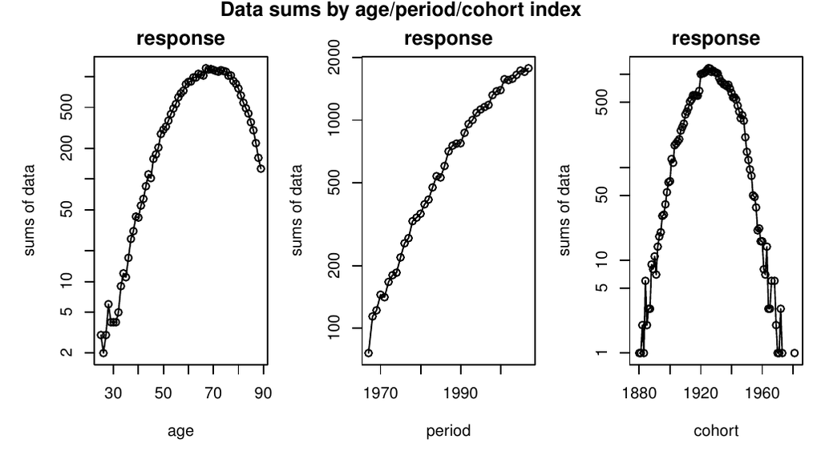

Figure 1: Data sums by age, by period and by cohort.

### 2.2 Descriptive plots

The *apc* package has a variety of plots for descriptive analysis. These include plots of sums of the data by age, period, or cohort to get an idea of the aggregate development; plots of the data matrix against two of the three time indices to spot patterns in the data; and sparsity plots indicating if some entries in the data matrix are very small. For instance, there are very few mesothelioma deaths for young people. These plots can be called and manipulated individually or they can be called with a single command, for example:

```r
> apc.plot.data.all(data.asbestos)
```

Figure 1 shows the plots of data sums. The responses are seen to be sparse for young people and for old and recent cohorts. The sparsity plot in Figure 2 illustrates this in more detail. It shows with black and grey entries in the data matrix with zero or one. The data are very sparse for young age groups and for old cohorts.

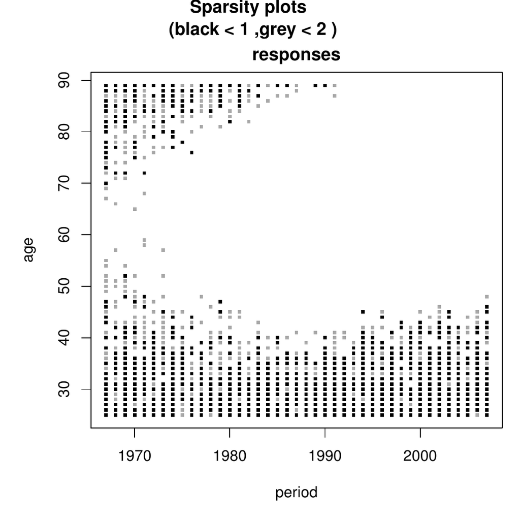

Figure 2: Sparsity plot.

### 2.3 Deviance analysis

At this point the distribution is chosen. Currently four distributions are implemented: A Poisson response model, a Poisson dose-response model, a logistic dose-response model, and a Gaussian model giving least squares regression. The sampling theory for the two Poisson models is described in Martínez Miranda et al. (2015) and Nielsen (2014), respectively.

The age-period-cohort model has a variety of interesting sub-models. These arise by setting some of the coordinates of the canonical parameter $\xi$ to zero. Nielsen (2014) gives a detailed discussion of the interpretation of the sub-models. An age-cohort model `"AC"` arises by setting the period double-differences to zero, so $\Delta^2\beta_j=0$ for $j=1,\dots ,J$. The drift models of Clayton and Schifflers (1987a,b) arise by setting two sets of double-differences to zero. An age-drift model `"Ad"` arises by setting the double differences $\Delta^2\beta _j$ and $\Delta^2\gamma_k$ to zero. Thus, it is a sub-model of `"AC"`. An age model code"A" arises by by setting $\Delta^2\beta _j$ , $\Delta^2\gamma_k$, and the cohort slope to zero. Thus, it is a sub-model of `"Ad"`. A trend model `"t"` is the linear plane where all double differences $\Delta^2\alpha_i$, $\Delta^2\beta _j$ and $\Delta^2\gamma_k$ are set to zero. Thus, it is a sub-model of `"Ad"`, but not nested in `"A"` as it has a cohort slope. An age trend model arises by setting all double differences $\Delta^2\alpha_i$, $\Delta^2\beta _j$ and $\Delta^2\gamma_k$ as well as the cohort slope to zero. Thus it is a sub-model of both `"t"` and `"Ad"`. Finally, an intercept model is denoted `"1"`. A deviance table gives an overview of the relative performance of the different models. For the mesothelioma data we get the following output.

```r
> apc.fit.table(data.asbestos, "poisson.response")
       -2logL df.residual prob(>chi_sq) LR.vs.APC df.vs.APC prob(>chi_sq)      aic
APC  2384.923        2457         0.848        NA        NA            NA 10805.81
AP   5336.034        2560         0.000  2951.111       103         0.000 13550.92
AC   2441.728        2496         0.778    56.805        39         0.033 10784.61
PC   8265.746        2520         0.000  5880.823        63         0.000 16560.63
Ad   5912.422        2599         0.000  3527.499       142         0.000 14049.31
Pd  23461.384        2623         0.000 21076.461       166         0.000 31550.27
Cd   8494.658        2559         0.000  6109.735       102         0.000 16711.54
A   21948.036        2600         0.000 19563.113       143         0.000 30082.92
P   34391.044        2624         0.000 32006.121       167         0.000 42477.93
C   28415.983        2560         0.000 26031.060       103         0.000 36630.87
t   24037.772        2662         0.000 21652.849       205         0.000 32048.66
tA  40073.386        2663         0.000 37688.463       206         0.000 48082.27
tP  34967.432        2663         0.000 32582.509       206         0.000 42976.32
tC  50558.531        2663         0.000 48173.607       206         0.000 58567.42
1   51003.046        2664         0.000 48618.123       207         0.000 59009.93
```

The first column in the table has the heading `-2logL`, noting that the deviance for Poisson and logistic models can be interpreted as minus twice the log likelihood for the model normalized to be zero in the saturated model. The deviance table indicates that the reduction worth considering is an age-cohort model, which is denoted `"AC"`. Moreover, the likelihood value and $p$-value for the `"APC"` model indicate that the quality of the unrestricted model is quite good, with a deviance smaller than the degrees of freedom.

### 2.4 Estimation of a particular model

We can look a bit closer at a particular sub-model. For instance, in the case of the asbestos data the unrestricted age-period-cohort model is estimated as follows. The estimation in *apc* is based on the representation ((9)). Along with the estimates we get standard errors, which are discussed below. The canonical parameter has 208 parameters, so only the first $8$ estimates are reported here.

```r
> fit.apc<- apc.fit.model(data.asbestos, "poisson.response", "APC")
> fit.apc$coefficients.canonical[1:8, ]
                 Estimate Std. Error      z value     Pr(>|z|)
level         1.041126756         NA           NA           NA
age slope     0.379386996  0.1115535  3.400941274 0.0006715425
cohort slope  0.358297074  0.1125026  3.184789061 0.0014485956
DD_age_27     1.029446394  1.6467618  0.625133761 0.5318832712
DD_age_28     0.065309039  1.4311381  0.045634337 0.9636017004
DD_age_29    -1.097279478  1.1180554 -0.981417831 0.3263867366
DD_age_30     0.414467808  1.1902557  0.348217448 0.7276768856
DD_age_31     0.003217972  1.2247555  0.002627441 0.9979036081
```

Note that the names for the parameters utilize the information about the real time scales coded through `apc.data.list()`.

For this data set exposure or dose is not available. We therefore apply the multinomial sampling scheme used in Martínez Miranda et al. (2015). With this approach we condition on the overall level of the data. The asymptotic distribution approximations will therefore be good in a situation where the dimension of the data is fixed and the total number of responses is large. Thus, in this response model we do not get standard errors for the level.

$$\label{eq:slopes}
\mu_{58,1968,1910}-\mu_{57,1967,1910}
,
\qquad
\mu_{57,1968,1911}-\mu_{57,1967,1910}
, \tag{6}$$

where any cell could be taken as a reference point. While the level and slopes have an explicit interpretation it is perhaps easier to interpret them in terms of a plot. Plots of the estimates are discussed below. While the package parametrises the linear plane in terms of the age and cohort slopes other choices could be made, such as age and period slopes. The age and cohort slopes are chosen due to the age and cohort symmetry of the model.

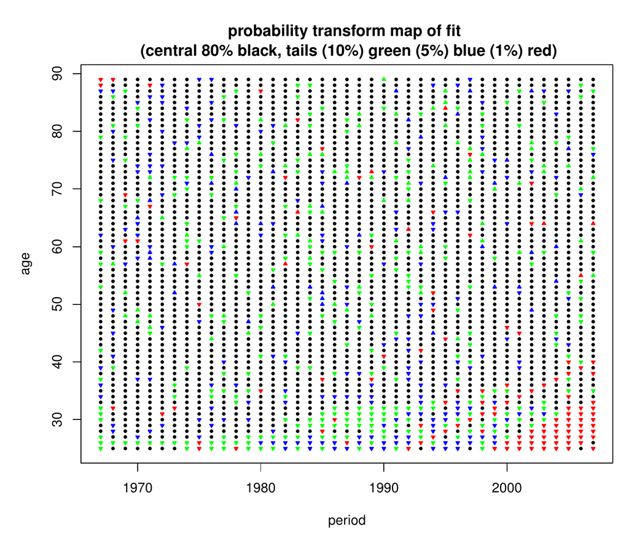

Figure 3: Probability transform plot of age-period-cohort fit to asbestos data.

### 2.5 A probability transform plot for the fit

The quality of the fit can be illustrated using a probability transform plot. Using the estimates it plots probability transforms of responses given the fitted value. In other words: are the actual observations probable given the estimated model? The plot is given in the original coordinate system. Colours and symbols are used to indicate whether responses are central to the fitted distribution or in the tails of the fitted distribution. The intention of the plot is to reveal if there are particularly many extreme observations given the fit and if they form a particular pattern.

For the asbestos data the probability transform plot is coded as:

```r
> apc.plot.fit.pt(fit.apc)
```

Figure 3 shows the result. For instance, all red point triangles indicates observations in the extreme 1 % of the distribution. Those pointing down indicate the lower end of the distribution. The number of red triangles is not particular large given the number of observations, $n=2665$, but, they form a pattern among the most recent cohorts. Therefore, a sub-sample analysis is performed below.

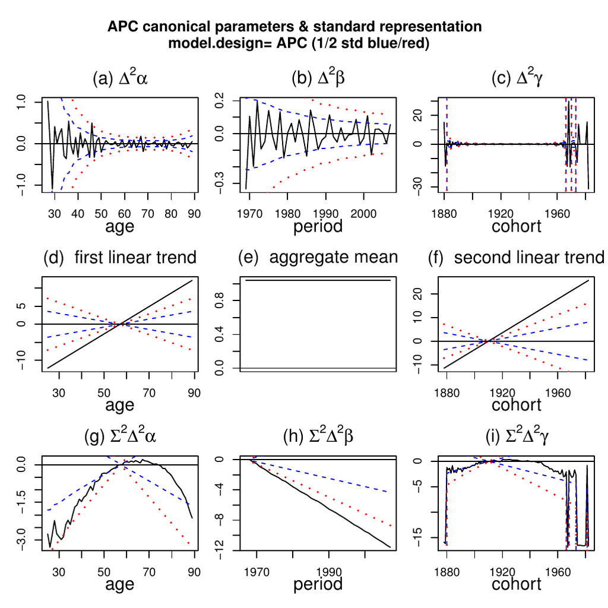

Figure 4: Plots of the fitted canonical parameters illustrating representation ((9)).

### 2.6 Plots of the estimates

The estimates can be plotted using a single command. This command will automatically pick up information about which sub-model and adjust accordingly, based on the analysis in Nielsen (2014). There are two types of plots, which are illustrated using a sequence of three plots. Details follow.

1. Figure 4. Plot of type `"sum.sum"`. This is illustrates the canonical parameter and the representation ((9)), but it is possibly the less useful choice in practical work.
2. Figure 5. Plot of type `"detrend"`. This is illustrates the representation ((10)). It is the default choice.
3. Figure 6. Plot of type `"detrend"` for a sub-sample. The above plots appear very messy, in part because of the sparsity. This evidence leads to a sub-sample, for which the estimates look much cleaner.

##### Plot of type `"sum.sum"`.

Figure 4 is generated by:

```r
> apc.plot.fit(fit.apc, type = "sum.sum")
```

It shows the canonical parameter estimates and illustrates the representation ((9)).

Figure 4 (a)–(c) shows the estimated second difference parameters $\Delta^2\alpha_i$, $\Delta^2\beta _j$, $\Delta^2\gamma_k$. The estimates are plotted with pointwise confidence bands centered around zero. The age double differences are noisy for young ages while the cohort double differences are noisy for young and old cohorts. This is due to the sparsity of observations for those age and cohort groups as shown in Figure 2. This calls for a sub-sample analysis, which is described below.

The next row of panels in Figure 4 illustrates the estimated level and the slopes ((6)). Panel (e) shows the estimated level of $1.04$. No confidence bands are shown due to the multinomial sampling scheme. Panels (d), (f) show the age and cohort slopes anchored at age $57$ and cohort $1910$ as discussed above.

Figure 4(g)–(i) shows double sums of double difference based on the representation ((9)). In each plot two values of the double sums are set to zero. In other words, the degrees of freedom, that is the number of non-zero values, in these plots are exactly the same as for the double differences. For exact values of the double sums see the last section of the paper.

The sum of the information in Figure 4(d)–(i) gives the linear predictor of the model. That, is for someone born in 1920 and dying at age 70 in 1990, the predictor is the sum of the linear age trend in (d) evaluated at 70, the level in (e), the linear cohort trend in (f) evaluated at 1920, the age effect in (g) evaluated at 70, the period effect in (h) evaluated at 1990, and the cohort effect in (i) evaluated at 1920.

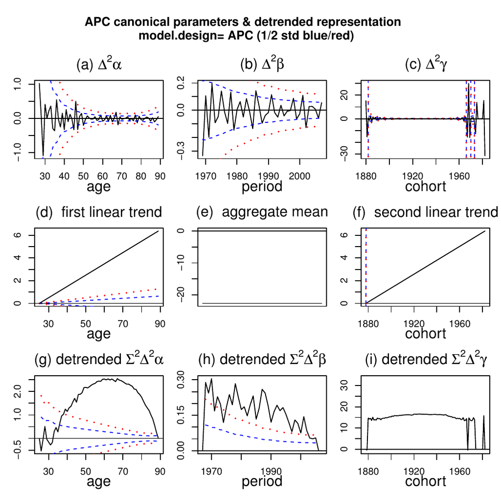

Figure 5: Plots of the fitted values using the detrended representation ((10)).

##### Plot of type `"detrend"`.

Figure 5 is generated by:

```r
> apc.plot.fit(fit.apc)
```

This plot illustrates the detrended representation ((10)). Figure 5(a)–(c) show exactly the same double differences as before.

The level, slopes and double sums in Figure 5(d)–(i) are now changed. The idea is to give a good visual impression of variation over and above a linear trend while preserving the degrees of freedom in panels (a)–(c). In this way Figure 5(g)–(i) show double sums of double differences detrended so as to start and end in zero. The level and slopes in Figure 5(d)–(f) are then changed according to representation ((10)). The interpretation is as before: The linear predictor for someone born in 1920 and dying at age 70 in 1990 is the sum of the linear age trend in (d) evaluated at 70, the level in (e), the linear cohort trend in (f) evaluated at 1920, the detrended age effect in (g) evaluated at 70, the detrended period effect in (h) evaluated at 1990, and the detrended cohort effect in (i) evaluated at 1920.

There are several noteworthy features of the detrended plots. The detrended double sums in Figure 5(g)–(i) fill the plot area better than those in Figure 4(g)–(i). Visually, it is easier to abstract from the arbitrary linear trend and focus on deviation from the linear trend. A possible drawback of the detrended plot is that age-period-cohort models can have perfect fit in some corners of the data array. For an age-period array, the very first and last cohort double differences will therefore be based on one data entry each. When looking at the detrended double sums those double differences are, however, combined with double sums of all the other double differences which are better determined.

The detrended age double sums in Figure 5(g) are broadly similar to those in Figure 4(g) apart from a lift in the scale and a slight change of slope. The plot indicates a near concave deviation from linearity after age 35. The development over the range 25-35 could be driven by the sparsity of the data in that region. We return to this point in the sub-sample analysis.

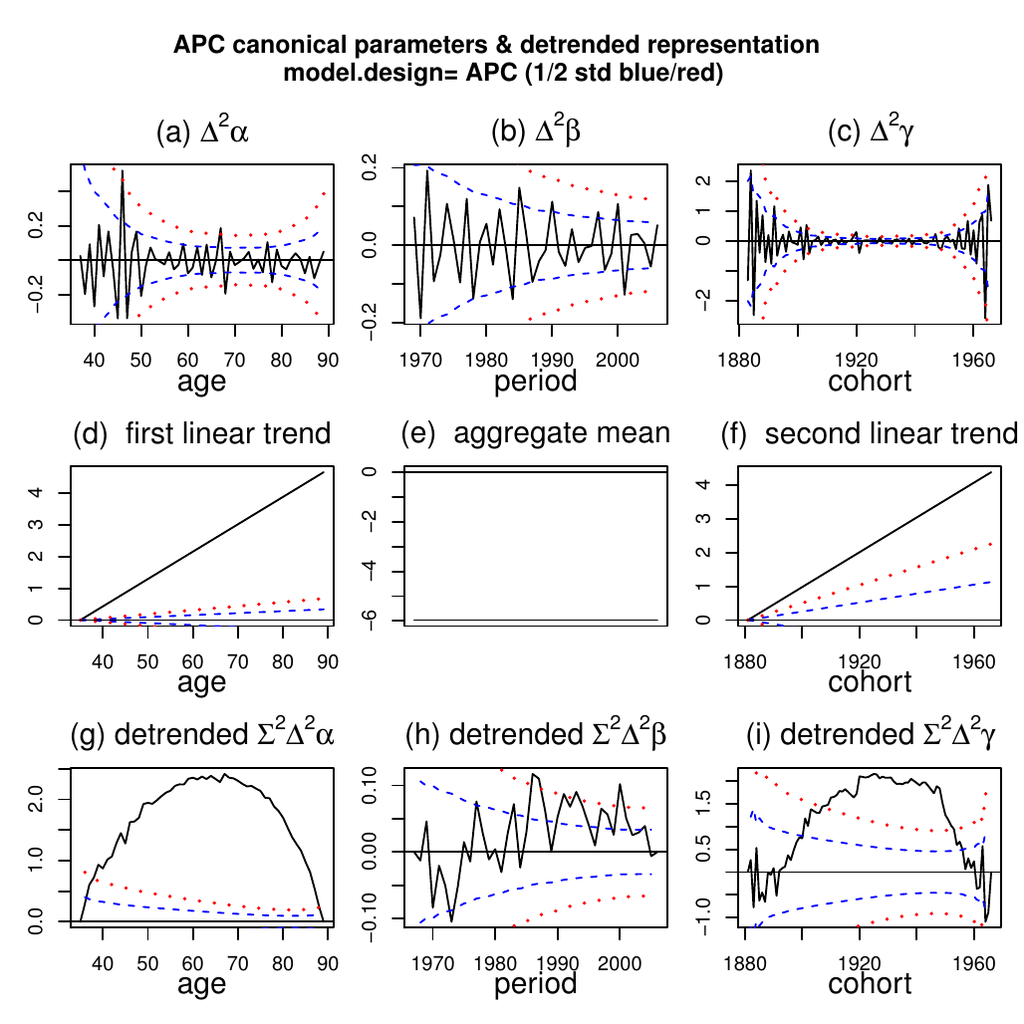

Figure 6: Plots of the fitted values for sub-sample.